Moncef Karim AIT BELKACEM; travail non finalisee:

```
- refaire l'echantillonage (limiter les cas extremes en multipliant les tests)
- faire le travail sur les 2 algorithmes restants
- mettre les accents (~claviers sans accents)
- La methode mathematique est correcte (math appliquees - taux d'erreurs)
```

# Grand Oral de Mathematique:

> **Comment évaluer l'efficacité d'un algorithme ?**

> **Introduction:** Plusieurs algorithmes nous permettent d'effectuer le meme traitement de l'information;  
> neanmoins certains sont plus efficaces que d'autres suivant la quantite de donnees a traiter.

> **Etude de cas:**

> ```
>     Nous cherchons à trier une liste de nombres par ordre croissant
>     Nous considérons quatre algorithmes:
>         1. Quick Sort
>         2. Bubble Sort
>         3. Insertion Sort
>         4. Bogo Sort
> ```

# Algorithme 1: Quick Sort

```python
def quickSort(arr):
    """Sort array using Bubble Sort"""
    elements = len(arr)
    if elements < 2:
        return arr
    current_position = 0
    for i in range(1, elements):
         if arr[i] <= arr[0]:
              current_position += 1
              temp = arr[i]
              arr[i] = arr[current_position]
              arr[current_position] = temp
    temp = arr[0]
    arr[0] = arr[current_position]
    arr[current_position] = temp
    left = quickSort(arr[0:current_position])
    right = quickSort(arr[current_position+1:elements])
    arr = left + [arr[current_position]] + right
    return arr
```

[figure not shown]

```python
liste_de_noms = ["jamy","fred","sabine","marcel"]
quickSort(liste_de_noms)
```

```
['fred', 'jamy', 'marcel', 'sabine']
```

# Algorithme 2: Bubble Sort

```python
def bubbleSort(array):
    """Sort array using Bubble Sort"""
    arr = list(array)
    n = len(arr)
    for i in range(n-1):
        for j in range(0, n-i-1):
            if arr[j] > arr[j+1] :
                arr[j], arr[j+1] = arr[j+1], arr[j]
    return arr
```

[figure not shown]

```python
liste_de_noms = ["jamy","fred","sabine","marcel"]
bubbleSort(liste_de_noms)
```

```
['fred', 'jamy', 'marcel', 'sabine']
```

# Algorithme 3: Insertion Sort

```python
def insertionSort(array):
    """"Sort array using Insertion Sort"""
    arr = list(array)
    for i in range(1, len(arr)):
        key = arr[i]
        j = i-1
        while j >=0 and key < arr[j] :
                arr[j+1] = arr[j]
                j -= 1
        arr[j+1] = key
    return arr
```

[figure not shown]

```python
liste_de_noms = ["jamy","fred","sabine","marcel"]
insertionSort(liste_de_noms)
```

```
['fred', 'jamy', 'marcel', 'sabine']
```

# Algorithme 4: Bogo Sort

```python
def bogoSort(array):
    """Sort arr using Bogo Sort"""
    arr = list(array)
    from random import randint
    def is_sorted(a):
        n = len(a)
        for i in range(0, n-1):
            if (a[i] > a[i+1] ):
                return False
        return True
    def shuffle(a):
        n = len(a)
        for i in range (0,n):
            r = randint(0,n-1)
            a[i], a[r] = a[r], a[i]
    n = len(arr)
    while (is_sorted(arr)== False):
        shuffle(arr)
    return arr
```

[figure not shown]

```python
liste_de_noms = ["jamy","fred","sabine","marcel"]
bogoSort(liste_de_noms)
```

```
['fred', 'jamy', 'marcel', 'sabine']
```

# Graphe des temps d'execution:

Nous executons et chronometrons 3 des 4 algorithmes:

- Quick Sort
- Insertion Sort
- Bubble Sort

```python
from numpy import float64
from time import perf_counter as now
from json import loads
from sys import setrecursionlimit
setrecursionlimit(10**6)

with open("numbers.json","r") as d:
    data = loads(d.read())

quick_time_list = []
insertion_time_list = []
bubble_time_list = []

for i in range(2, 5002):
    subdata = data[:i]
    print(i, end=" | ")

    quick_time_start = float64(now())
    quickSort(subdata)
    quick_time_end = float64(now())
    quick_execution_time = quick_time_end - quick_time_start
    quick_time_list.append(quick_execution_time)

    insertion_time_start = float64(now())
    insertionSort(subdata)
    insertion_time_end = float64(now())
    insertion_execution_time = insertion_time_end - insertion_time_start
    insertion_time_list.append(insertion_execution_time)

    bubble_time_start = float64(now())
    bubbleSort(subdata)
    bubble_time_end = float64(now())
    bubble_execution_time = bubble_time_end - bubble_time_start
    bubble_time_list.append(bubble_execution_time)

import matplotlib.pyplot as plt
plt.scatter(range(2, 5002), quick_time_list,label="quick", marker='o',color="blue", s=10)
plt.scatter(range(2, 5002), bubble_time_list, marker='o', label="bubble", color="red", s=10)
plt.scatter(range(2, 5002), insertion_time_list, marker='o', label="insertion", color='black', s=10)
plt.xlabel("list length")
plt.ylabel("time")
plt.legend()
plt.show()
plt.rcParams['figure.figsize'] = [120, 70]
plt.show()
```

[figure not shown]

Sur la figure ci-contre:  
des points d'abcisse L (longueur de la liste {2,5002}) et d'ordonnée T (temps d'execution de l'agorithme de tri).  
Bubble Sort **•** Insertion Sort **•** Quick Sort **•**  
On remarque la presence de courbes principales et de points dispersés ça et là; le chronometrage est une mesure peu exacte, nous nous contenterons d'etudier les points les plus proches de la courbe.  
Les valeurs importent peu, leur evolution est l'objectif de notre etude.  
C'est pour cela qu nous utiliserons des abcisses plus eloignés (limiter la marge d'erreur (de 2 à 50000))

```
2 | 5002 | 10002 | 15002 | 20002 | 25002 | 30002 | 35002 | 40002 | 45002 |
```

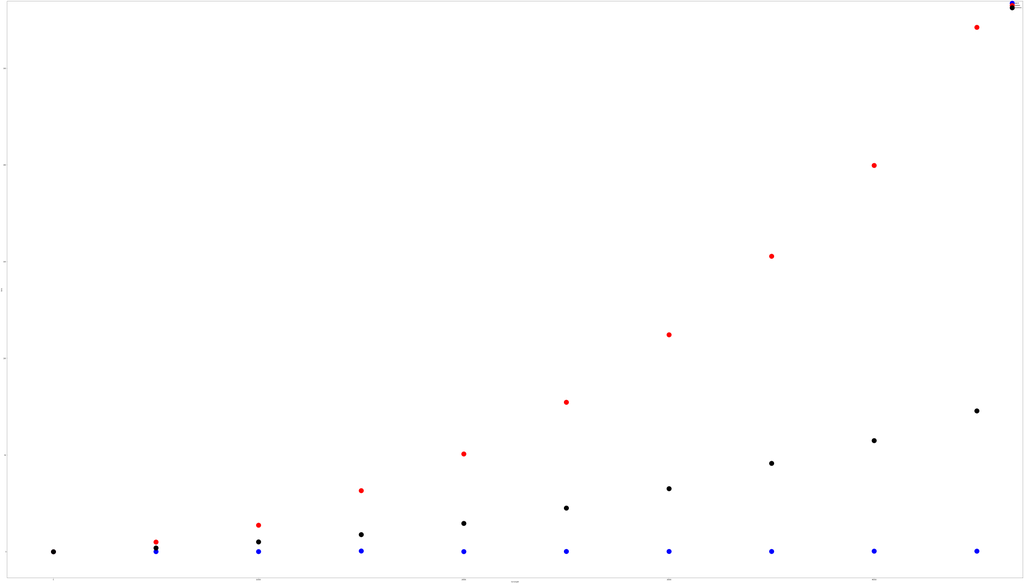

```python
from numpy import float64
from time import perf_counter as now
from json import loads
from sys import setrecursionlimit
setrecursionlimit(10**6)

with open("numbers.json","r") as d:
    data = loads(d.read())

quick_time_list = []
insertion_time_list = []
bubble_time_list = []

for i in range(2, 50000,5000):
    subdata = data[:i]
    print(i, end=" | ")

    quick_time_start = float64(now())
    quickSort(subdata)
    quick_time_end = float64(now())
    quick_execution_time = quick_time_end - quick_time_start
    quick_time_list.append(quick_execution_time)

    insertion_time_start = float64(now())
    insertionSort(subdata)
    insertion_time_end = float64(now())
    insertion_execution_time = insertion_time_end - insertion_time_start
    insertion_time_list.append(insertion_execution_time)

    bubble_time_start = float64(now())
    bubbleSort(subdata)
    bubble_time_end = float64(now())
    bubble_execution_time = bubble_time_end - bubble_time_start
    bubble_time_list.append(bubble_execution_time)

import matplotlib.pyplot as plt
plt.scatter(range(2, 50000,5000), quick_time_list,label="quick", marker='o',color="blue", s=1000)
plt.scatter(range(2, 50000, 5000), bubble_time_list, marker='o', label="bubble", color="red", s=1000)
plt.scatter(range(2, 50000, 5000), insertion_time_list, marker='o', label="insertion", color='black', s=1000)
plt.xlabel("list length")
plt.ylabel("time")
plt.legend()
plt.rcParams['figure.figsize'] = [120, 70]
plt.show()
```

Bubble Sort **•** Insertion Sort **•** Quick Sort **•**  
Le tableau ci-dessous regroupe ces valeurs.

```python
from pandas import Series, DataFrame, concat
q = DataFrame(quick_time_list, index=range(2, 50000, 5000))
b = DataFrame(bubble_time_list, index=range(2, 50000, 5000))
I = DataFrame(insertion_time_list, index=range(2, 50000, 5000))
a = concat([q,b,I], axis=1)
a.columns=["Quick Sort","Bubble Sort","Insertion Sort"]
a
```

|  | Quick Sort | Bubble Sort | Insertion Sort |
| --- | --- | --- | --- |
| 2 | 0.000018 | 0.000006 | 0.000006 |
| 5002 | 0.042743 | 4.967089 | 1.930441 |
| 10002 | 0.046710 | 13.705083 | 5.089626 |
| 15002 | 0.391331 | 31.601418 | 8.817992 |
| 20002 | 0.100364 | 50.548779 | 14.631031 |
| 25002 | 0.128250 | 77.269351 | 22.564628 |
| 30002 | 0.154332 | 112.188078 | 32.565380 |
| 35002 | 0.181586 | 152.822460 | 45.695084 |
| 40002 | 0.266142 | 199.794240 | 57.489762 |
| 45002 | 0.303592 | 271.214856 | 72.818693 |

# Definir l'expression des courbes

## Definir l'expression des derivees

> La derivee de la fonction de la courbe $C_{bubble}$ est la fonction qui pour chaque abcisse *x*, associe *y*  
> le coefficient directeur de $C_{bubble}$ au point *(x,y)*  
> Tracons les tangentes en chaque point *p*  
> Pour tracer la tangente en un point *p* a la courbe *C*, on calcule le coefficient directeur de la droite passant par les points *p-1* et *p+1* (points adjacents sur la courbe).  
> Cette tangente est de la forme *ax+b= y* ou *a = $\frac{y_{p+1}-y_{p-1}}{x_{p+1}-x_{p-1}}$*

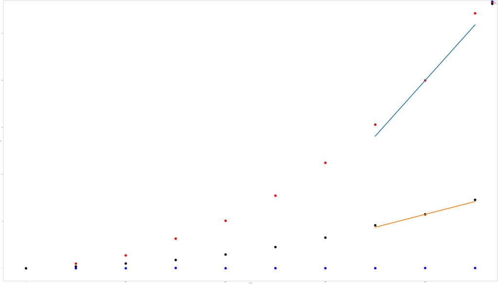

```python
plt.plot([35002, 45002],[float64(152.822460-12.3),float64(271.214856-12.3)], linewidth=10)
plt.plot([35002, 45002],[float64(45.489762-1.8),float64(72.818693-1.8)], linewidth=10)
plt.scatter(range(2, 50000,5000), quick_time_list,label="quick", marker='o',color="blue", s=1000)
plt.scatter(range(2, 50000, 5000), bubble_time_list, marker='o', label="bubble", color="red", s=1000)
plt.scatter(range(2, 50000, 5000), insertion_time_list, marker='o', label="insertion", color='black', s=1000)
plt.xlabel("list length")
plt.ylabel("time")
plt.legend()
plt.rcParams['figure.figsize'] = [120, 70]
plt.show()
```

Nous remplissons les tableaux suivants; en utilisant l'approximation ci-dessous:  
exemple QuickSort pour x=5002:

> *f'* (5002)≈ $\frac{f(10002)-f(2)}{10002-2}$

Quick Sort

[output not shown]

Bubble Sort

| x | f(x)=y | f'(x) |
| --- | --- | --- |
| 2 | 0.000006 | ----- |
| 5002 | 4.967089 | 0.0013705077 |
| 10002 | 13.705083 | 0.0026634329 |
| 15002 | 31.601418 | 0.0036843696 |
| 20002 | 50.548779 | 0.0045667933 |
| 25002 | 77.269351 | 0.0061639299 |
| 30002 | 112.188078 | 0.0075553109 |
| 35002 | 152.822460 | 0.0087606162 |
| 40002 | 199.794240 | 0.0118392396 |
| 45002 | 271.214856 | ----- |

Insertion Sort

| x | y | f'(x) |
| --- | --- | --- |
| 2 | 0.000006 | ----- |
| 5002 | 1.930441 |  |
| 10002 | 5.089626 |  |
| 15002 | 8.817992 |  |
| 20002 | 14.631031 |  |
| 25002 | 22.564628 |  |
| 30002 | 32.565380 |  |
| 35002 | 45.695084 |  |
| 40002 | 57.489762 |  |
| 45002 | 72.818693 | ----- |

### Prediction BubbleSort

> dans un premier temps nous etudierons l'evolution du temps d'execution de l'algorithme BubbleSort. Pour cela nous utilisons les valeurs de *f'(x)* du tableau ci-dessus.

[figure not shown]

```python
derivee_bubble=[
0.0013705077,
0.0026634329,
0.0036843696,
0.0045667933,
0.0061639299,
0.0075553109,
0.0087606162,
0.0118392396]
#0.0118392396

x_derivee_bubble = [
5002 ,
10002,
15002,
20002,
25002,
30002,
35002,
40002]
#40002
plt.plot([5002,35002],[0.0013705077,0.0087606162], linewidth=5, color='red')

plt.scatter(x_derivee_bubble,derivee_bubble,marker='o', s=1500)
plt.show()
```

En placant sur un graphe les differentes valeurs de *f'(x)* (Bubble Sort); on remarque que les points semblent se distribuer autour d'une droite.  
On peut alors dire que f'(x) est une fonction affine qui peut s'ecrire sous la forme *ax+b*.

La droite passant par le point (5002, 0.0013705077) et le point (35002, 0.0087606162) est la meilleure approximation.

*a* est le coefficient directeur de cette droite:

exemple: f(22000) = 75.151149

```python
from numpy import float64
from time import perf_counter as now
from json import loads
from sys import setrecursionlimit
setrecursionlimit(10**6)

with open("numbers.json","r") as d:
    data = loads(d.read())
b = float64(now())
bubbleSort(data[:22000])
b2 = float64(now())
t = b2 - b
t
```

```
77.9425115050035
```